# EEA - TP1: Regresión lineal

Lisandro Carrasco

2022-10-16

## Análisis exploratorio

**Leer el archivo “encuesta_salud_train.csv”. ¿Qué puede mencionar sobre su estructura y variables?**

```r
train <- read.csv('encuesta_salud_train.csv', encoding = 'UTF-8')
test <- read.csv('encuesta_salud_test.csv', encoding = 'UTF-8')

test <- test %>%
  mutate_if(is.character, as.factor) %>%
  mutate(record = as.factor(record))

train <- train %>%
  mutate_if(is.character, as.factor) %>%
  mutate(record = as.factor(record))

glimpse(train)
```

```
## Rows: 7,024
## Columns: 16
## $ record                        <fct> 502, 26488, 31473, 14154, 36578, 53730, ~
## $ edad                          <int> 17, 15, 15, 16, 17, 15, 13, 17, 17, 16, ~
## $ genero                        <fct> Femenino, Masculino, Masculino, Masculin~
## $ nivel_educativo               <fct> 2do año/11vo grado nivel Polimodal o 4to~
## $ altura                        <int> 165, 178, 172, 170, 170, 178, 156, 163, ~
## $ peso                          <int> 62, 62, 62, 65, 75, 88, 46, 60, 57, 51, ~
## $ frecuencia_hambre_mensual     <fct> Rara vez, Rara vez, Nunca, Nunca, Rara v~
## $ dias_consumo_comida_rapida    <int> 0, 0, 3, 1, 1, 2, 0, 0, 0, 3, 4, 2, 1, 1~
## $ edad_consumo_alcohol          <fct> 14 o 15 años, 7 años o menos, Nunca tomé~
## $ consumo_diario_alcohol        <dbl> 5.0, 4.0, 0.0, 0.0, 0.0, 5.0, 1.0, 0.5, ~
## $ dias_actividad_fisica_semanal <int> 7, 7, 7, 7, 0, 7, 0, 2, 7, 3, 2, 2, 7, 1~
## $ consumo_semanal_frutas        <fct> No comí frutas durante los últimos 7 día~
## $ consumo_semanal_verdura       <fct> 4 a 6 veces durante los últimos 7 días, ~
## $ consumo_semanal_gaseosas      <fct> 1 a 3 veces durante los últimos 7 días, ~
## $ consumo_semanal_snacks        <fct> 1 a 3 veces durante los últimos 7 días, ~
## $ consumo_semanal_comida_grasa  <fct> No comí comida alta en grasa en los últi~
```

```r
exploracion <- train %>%
  gather(.,
         key = "variables",
         value = "valores") %>%
  group_by(variables) %>%
  summarise(valores_unicos = n_distinct(valores))
reactable(exploracion %>% select(
  "Variables" = variables,
  "Valores únicos" = valores_unicos
))
```

| Variables | Valores únicos |
| --- | --- |
| altura | 68 |
| consumo_diario_alcohol | 7 |
| consumo_semanal_comida_grasa | 8 |
| consumo_semanal_frutas | 8 |
| consumo_semanal_gaseosas | 8 |
| consumo_semanal_snacks | 8 |
| consumo_semanal_verdura | 8 |
| dias_actividad_fisica_semanal | 8 |
| dias_consumo_comida_rapida | 8 |
| edad | 7 |

[output cut: 6 more lines]

El dataframe de entrenamiento cuenta con 7.024 observaciones y 16 variables, 6 de las cuales son numéricas y el resto, categóricas. Más allá de que haya variables que se presentan como numéricas, muchas de ellas tienen un comportamiento discreto (puede apreciarse en la poca cantidad de valores únicos que tienen), como la edad, el consumo diario de alcohol, de comida rápida y la frecuencia semanal de actividad física. Por otro lado, las variables que brindan información sobre consumos semanales se tratarán como factores expresados en caracteres. Finalmente, el dataframe no presenta valores faltantes en ninguna de sus columnas.

```r
any(is.na(train))
```

```
## [1] FALSE
```

```r
rm(exploracion)
```

**¿Cómo es la correlación entre las variables numéricas? Utilice y analice en detalle algún gráfico que sirva para sacar conclusiones sobre la asociación de variables realizando apertura por género.**

```r
numericas <- train %>%
  select_if(is.numeric) %>%
  colnames()

numericas <- train %>%
  select(genero, numericas)
```

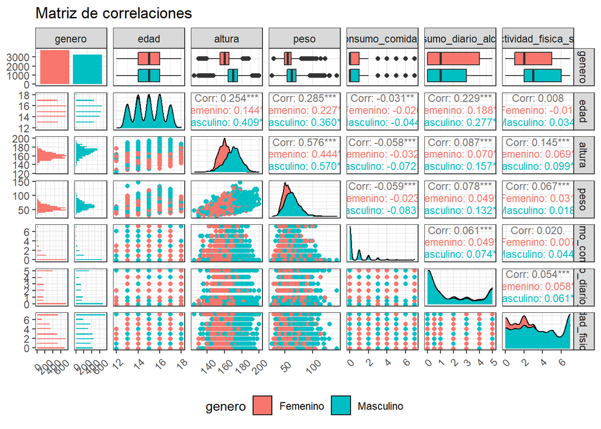

```r
numericas%>%
  mutate(genero = as.factor(genero)) %>%
  ggpairs(., mapping = aes(colour = genero), title = "Matriz de correlaciones",
          upper = list(continuous = wrap("cor", size = 3, hjust=0.5)), legend = 25) +
  theme_bw() +
  theme(axis.text.x = element_text(angle=45, vjust=0.5), legend.position = "bottom")
```

Algunas apreciaciones generales sobre el gráfico:

- Aperturando por género, pueden verse comportamientos esperables, por ejemplo, que la mediana de la altura y el peso sea mayor en los hombres que en las mujeres.
- Por otro lado, hay datos llamativos, como el hecho de que si bien comparten la mediana del consumo diario de alcohol, en las mujeres el tercer cuartil se extiende bastante más.
- También puede verse un mayor nivel de actividad física entre los hombres que entre las mujeres.
- Finalmente, hay que destacar la correlación positiva entre el consumo diario de alcohol y la edad, entendiendo que a mayor edad, mayor el consumo esperado de alcohol.

**En particular, ¿cómo es la correlación entre la variable a explicar (peso) y el resto de las variables numéricas?**

```r
pearson <- train %>%
  select(peso, edad, altura, dias_consumo_comida_rapida, consumo_diario_alcohol,
         dias_actividad_fisica_semanal) %>%
  correlate() %>%
  shave() %>%
  fashion()

reactable(pearson)
```

| term | peso | edad | altura | dias_consumo_comida_rapida | consumo_diario_alcohol | dias_actividad_fisica_semanal |
| --- | --- | --- | --- | --- | --- | --- |
| peso |  |  |  |  |  |  |
| edad | .28 |  |  |  |  |  |
| altura | .58 | .25 |  |  |  |  |
| dias_consumo_comida_rapida | -.06 | -.03 | -.06 |  |  |  |
| consumo_diario_alcohol | .08 | .23 | .09 | .06 |  |  |
| dias_actividad_fisica_semanal | .07 | .01 | .15 | .02 | .05 |  |

```r
spearman <- train %>%
  select(peso, edad, altura, dias_consumo_comida_rapida, consumo_diario_alcohol,
         dias_actividad_fisica_semanal) %>%
  correlate(method = 'spearman') %>%
  shave() %>%
  fashion()

reactable(spearman)
```

| term | peso | edad | altura | dias_consumo_comida_rapida | consumo_diario_alcohol | dias_actividad_fisica_semanal |
| --- | --- | --- | --- | --- | --- | --- |
| peso |  |  |  |  |  |  |
| edad | .30 |  |  |  |  |  |
| altura | .59 | .24 |  |  |  |  |
| dias_consumo_comida_rapida | -.05 | -.02 | -.05 |  |  |  |
| consumo_diario_alcohol | .10 | .25 | .10 | .08 |  |  |
| dias_actividad_fisica_semanal | .09 | .01 | .15 | .02 | .05 |  |

Las correlaciones con el método de Spearman tienen muy pocos cambios.

```r
cor.test(train$peso, train$edad, method = "pearson")
```

```
##
##  Pearson's product-moment correlation
##
## data:  train$peso and train$edad
## t = 24.885, df = 7022, p-value < 0.00000000000000022
## alternative hypothesis: true correlation is not equal to 0
## 95 percent confidence interval:
##  0.2630440 0.3060288
## sample estimates:
##       cor
## 0.2846795
```

```r
cor.test(train$peso, train$altura, method = "pearson")
```

```
##
##  Pearson's product-moment correlation
##
## data:  train$peso and train$altura
## t = 59.044, df = 7022, p-value < 0.00000000000000022
## alternative hypothesis: true correlation is not equal to 0
## 95 percent confidence interval:
##  0.5601425 0.5914042
## sample estimates:
##       cor
## 0.5759839
```

```r
cor.test(train$peso, train$edad, method = "spearman")
```

```
##
##  Spearman's rank correlation rho
##
## data:  train$peso and train$edad
## S = 40675935803, p-value < 0.00000000000000022
## alternative hypothesis: true rho is not equal to 0
## sample estimates:
##       rho
## 0.2957363
```

```r
cor.test(train$peso, train$altura, method = "spearman")
```

```
##
##  Spearman's rank correlation rho
##
## data:  train$peso and train$altura
## S = 23945985933, p-value < 0.00000000000000022
## alternative hypothesis: true rho is not equal to 0
## sample estimates:
##       rho
## 0.5853989
```

Los p valores de ambos test muestran que existe **evidencia a favor de la asociación lineal** entre la edad y la altura con el peso.

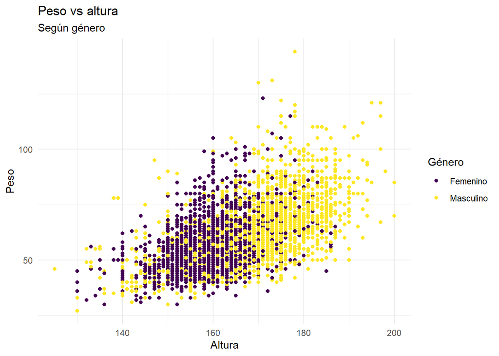

```r
ggplot() +
  geom_point(data = train, aes(x = altura, y = peso, color = genero)) +
  theme_minimal() +
  scale_color_viridis(discrete = TRUE)+
  labs(x="Altura", y="Peso", color = "Género",
       title = "Peso vs altura", subtitle = "Según género")
```

El gráfico de puntos muestra la **correlación positiva entre la altura y el peso**. Este gráfico tendría menos sentido en el caso de la edad, dado que los valores, si bien numéricos para el dataframe, tienen un sentido más categórico al ser discretos.

**Para las categorías de la variable frecuencia de hambre mensual, analice gráficamente la distribución en términos de frecuencia relativa de:**  
**a) El consumo semanal de verdura.**  
**b) El consumo semanal de comida grasa.¿Cuáles son las principales características que observa en estos gráficos?**

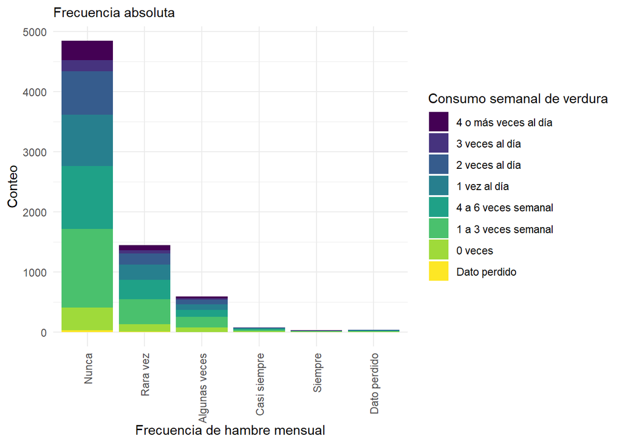

```r
hambre <- train %>%
  select(frecuencia_hambre_mensual, consumo_semanal_verdura, consumo_semanal_comida_grasa)

hambre$frecuencia_hambre_mensual <- factor(hambre$frecuencia_hambre_mensual,
                                           levels = c("Nunca",
                                                       "Rara vez",
                                                       "Algunas veces",
                                                       "Casi siempre",
                                                       "Siempre",
                                                       "Dato perdido"))

hambre$consumo_semanal_verdura <- factor(hambre$consumo_semanal_verdura,
                                           levels = c(
                                             "4 o más veces al día",
                                             "3 veces al día",
                                             "2 veces al día",
                                             "1 vez al día",
                                             "4 a 6 veces durante los últimos 7 días",
                                             "1 a 3 veces durante los últimos 7 días",
                                            "No comí verduras ni hortalizas durante los últimos 7 días",
                                            "Dato perdido"))

levels(hambre$consumo_semanal_verdura)[5] <- "4 a 6 veces semanal"
levels(hambre$consumo_semanal_verdura)[6] <- "1 a 3 veces semanal"
levels(hambre$consumo_semanal_verdura)[7] <- "0 veces"

ggplot(data = hambre) +
  geom_bar(mapping = aes(x = frecuencia_hambre_mensual, fill = consumo_semanal_verdura)) +
  viridis::scale_fill_viridis(discrete = TRUE) +
  theme_minimal() +
  theme(axis.text.x = element_text(angle = 90, vjust = 0.5, hjust=1)) +
  labs(x = "Frecuencia de hambre mensual", y = "Conteo", fill = "Consumo semanal de verdura", subtitle = "Frecuencia absoluta")
```

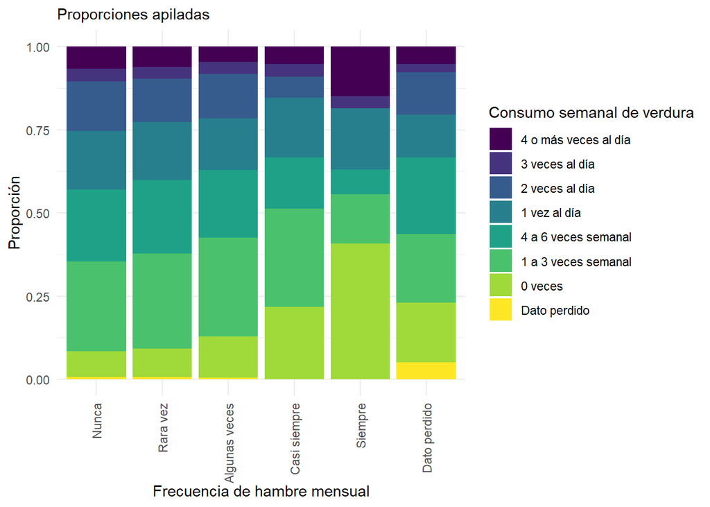

```r
ggplot(data = hambre) +
  geom_bar(mapping = aes(x = frecuencia_hambre_mensual, fill = consumo_semanal_verdura), position = "fill") +
  viridis::scale_fill_viridis(discrete = TRUE) +
  theme_minimal() +
  theme(axis.text.x = element_text(angle = 90, vjust = 0.5, hjust=1)) +
  labs(x = "Frecuencia de hambre mensual", y = "Proporción", fill = "Consumo semanal de verdura", subtitle = "Proporciones apiladas")
```

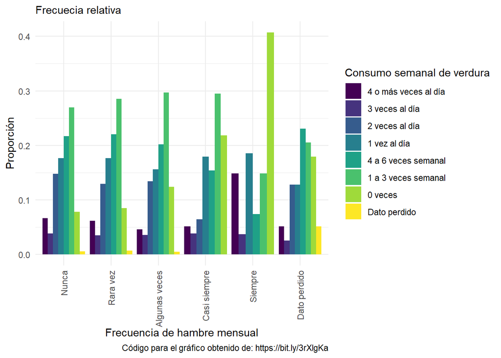

```r
hambre_relat <- hambre %>%
  group_by(frecuencia_hambre_mensual) %>%
  add_count(name="n")%>%
  ungroup()%>%
  group_by(frecuencia_hambre_mensual, consumo_semanal_verdura)%>%
  add_count(name="n1")%>%
  transform(norm_count=n1/n)%>%
  distinct(frecuencia_hambre_mensual,consumo_semanal_verdura,n,n1,norm_count)


ggplot(data=hambre_relat)+
  geom_bar(mapping = aes(x=frecuencia_hambre_mensual, y=norm_count,
           fill=consumo_semanal_verdura),
           stat="identity", position="dodge") +
  viridis::scale_fill_viridis(discrete = TRUE) +
  theme_minimal() +
  theme(axis.text.x = element_text(angle = 90, vjust = 0.5, hjust=1)) +
  labs(x = "Frecuencia de hambre mensual", y = "Proporción", fill = "Consumo semanal de verdura", subtitle = "Frecuecia relativa", caption = "Código para el gráfico obtenido de: https://bit.ly/3rXlgKa")
```

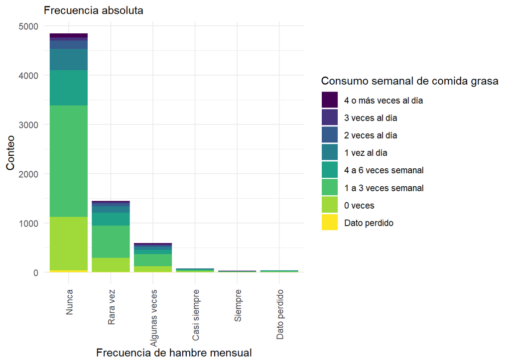

```r
hambre$consumo_semanal_comida_grasa <- factor(hambre$consumo_semanal_comida_grasa,
                                           levels = c(
                                             "4 o más veces al día",
                                             "3 veces al día",
                                             "2 veces al día",
                                             "1 vez al día",
                                             "4 a 6 veces durante los últimos 7 días",
                                             "1 a 3 veces durante los últimos 7 días",
                                            "No comí comida alta en grasa en los últimos 7 días",
                                            "Dato perdido"))

levels(hambre$consumo_semanal_comida_grasa)[5] <- "4 a 6 veces semanal"
levels(hambre$consumo_semanal_comida_grasa)[6] <- "1 a 3 veces semanal"
levels(hambre$consumo_semanal_comida_grasa)[7] <- "0 veces"

ggplot(data = hambre) +
  geom_bar(mapping = aes(x = frecuencia_hambre_mensual, fill = consumo_semanal_comida_grasa)) +
  viridis::scale_fill_viridis(discrete = TRUE) +
  theme_minimal() +
  theme(axis.text.x = element_text(angle = 90, vjust = 0.5, hjust=1)) +
  labs(x = "Frecuencia de hambre mensual", y = "Conteo", fill = "Consumo semanal de comida grasa", subtitle = "Frecuencia absoluta")
```

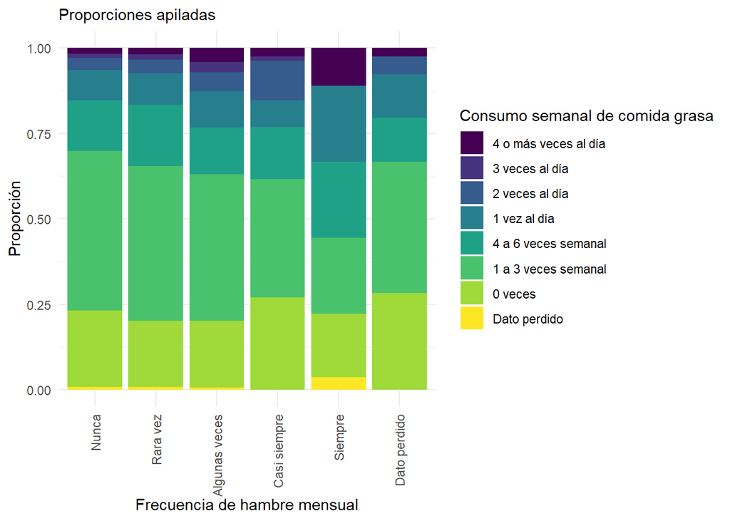

```r
ggplot(data = hambre) +
  geom_bar(mapping = aes(x = frecuencia_hambre_mensual, fill = consumo_semanal_comida_grasa), position = "fill") +
  viridis::scale_fill_viridis(discrete = TRUE) +
  theme_minimal() +
  theme(axis.text.x = element_text(angle = 90, vjust = 0.5, hjust=1)) +
  labs(x = "Frecuencia de hambre mensual", y = "Proporción", fill = "Consumo semanal de comida grasa", subtitle = "Proporciones apiladas")
```

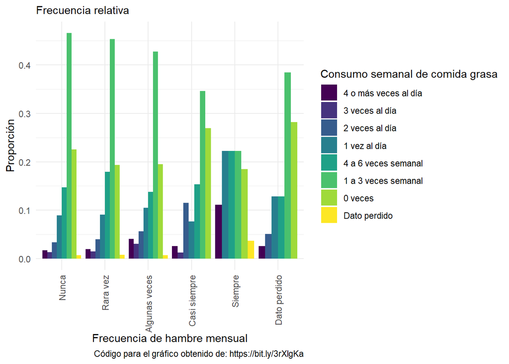

```r
hambre_relat <- hambre %>%
  group_by(frecuencia_hambre_mensual) %>%
  add_count(name="n")%>%
  ungroup()%>%
  group_by(frecuencia_hambre_mensual, consumo_semanal_comida_grasa)%>%
  add_count(name="n1")%>%
  transform(norm_count=n1/n)%>%
  distinct(frecuencia_hambre_mensual,consumo_semanal_comida_grasa,n,n1,norm_count)


ggplot(data=hambre_relat)+
  geom_bar(mapping = aes(x=frecuencia_hambre_mensual, y=norm_count,
           fill=consumo_semanal_comida_grasa),
           stat="identity", position="dodge") +
  viridis::scale_fill_viridis(discrete = TRUE) +
  theme_minimal() +
  theme(axis.text.x = element_text(angle = 90, vjust = 0.5, hjust=1)) +
  labs(x = "Frecuencia de hambre mensual", fill = "Consumo semanal de comida grasa", y = "Proporción", subtitle = "Frecuencia relativa", caption = "Código para el gráfico obtenido de: https://bit.ly/3rXlgKa")
```

En primera instancia, puede verse que son pocos los casos donde los encuestados responden pasar hambre. La amplia mayoría dice que nunca lo pasó o que rara vez le sucedió.

Finalmente, es interesante ver el comportamiento de los pocos encuestados que siempre dicen pasar hambre: este es el grupo que tiene una mayor porpoción de consumidores de comidas grasas en las tres categorías más frecuentes, mientras que son los que más declaran haber comido 0 veces verduras en la semana.

Si bien es una muestra altamente desbalanceada, es interesante pensar en términos de un patrón de asociación entre alimentación saludable y capacidad económica.

## Modelo inicial

Se plantea que una primera alternativa para modelar el peso es:

*E(peso) = β0 +β1altura+β2edad+β3genero+β4diasActividadF isicaSemanal+β5consumoDiarioAlcohol*

¿Cuál es la interpretación de cada uno de los coeficientes estimados?  
¿Son significativos?  
¿El modelo resulta significativo para explicar el peso?  
¿Qué porcentaje de la variabilidad explica el modelo?

#### Modelo numérico inicial

```r
modelo_inicial <- lm(peso ~ altura + edad + genero + dias_actividad_fisica_semanal + consumo_diario_alcohol,
                     data = train)
reactable(tidy(modelo_inicial, conf.int = TRUE))
```

| term | estimate | std.error | statistic | p.value | conf.low | conf.high |
| --- | --- | --- | --- | --- | --- | --- |
| (Intercept) | -68.9226880697962 | 2.33805444918447 | -29.4786496926267 | 3.61486599608226e-180 | -73.5059810428752 | -64.3393950967172 |
| altura | 0.650606543901329 | 0.0143797499811326 | 45.244635320849 | 0 | 0.622417890268328 | 0.67879519753433 |
| edad | 1.40672706010646 | 0.0938508100956944 | 14.9889708855161 | 5.1215989492541e-50 | 1.22275112294238 | 1.59070299727054 |
| generoMasculino | 1.26264355831348 | 0.272828210237404 | 4.62798021221771 | 3.75883098783742e-06 | 0.727817853430954 | 1.797469263196 |
| dias_actividad_fisica_semanal | -0.0873910313833703 | 0.0499291717404228 | -1.75030004178135 | 0.0801102500290618 | -0.185267290026258 | 0.0104852272595173 |
| consumo_diario_alcohol | 0.00727137928074718 | 0.0613855818538552 | 0.118454188445401 | 0.905711181897993 | -0.113062903805464 | 0.127605662366958 |

Interpretaciones de los **coeficientes**:

Es necesario señalar que estas interpretaciones tienen una condición necesaria: su interpretación se debe realizar haciendo una abstracción análitica según la cual todas las variables se fijan en un valor y solo se modifica la variable analizada en cuestión. Es decir, la interpretación del incremento del peso esperado por cada año de edad es solo válida en tanto la altura, el género y las otras variables se consideren fijas.

En términos de la **significativdad individual** de las variables, por sus p-valores, vemos que tanto la altura, la edad y el género son variables que tienen relaciones significativas con la variable dependiente (peso). En tanto vemos que el p-valor de la actividad física y el consumo de alcohol no nos permite rechazar la hipótesis nula y esto se refuerza al ver que sus intervalos de confianza contienen al 0.

En cuanto a la **significatividad global** del modelo, vemos el resumen de su información, que presenta el estadístico F y el p-valor asociado. Este p-valor nos indica que el modelo sí resulta significativo para explicar el peso.

```r
summary(modelo_inicial)
```

```
##
## Call:
## lm(formula = peso ~ altura + edad + genero + dias_actividad_fisica_semanal +
##     consumo_diario_alcohol, data = train)
##
## Residuals:
##     Min      1Q  Median      3Q     Max
## -28.014  -6.527  -1.104   5.050  76.143
##
## Coefficients:
##                                 Estimate Std. Error t value
## (Intercept)                   -68.922688   2.338054 -29.479
## altura                          0.650607   0.014380  45.245
## edad                            1.406727   0.093851  14.989
## generoMasculino                 1.262644   0.272828   4.628
## dias_actividad_fisica_semanal  -0.087391   0.049929  -1.750
## consumo_diario_alcohol          0.007271   0.061386   0.118
##                                           Pr(>|t|)
## (Intercept)                   < 0.0000000000000002 ***
## altura                        < 0.0000000000000002 ***
## edad                          < 0.0000000000000002 ***
## generoMasculino                         0.00000376 ***
## dias_actividad_fisica_semanal               0.0801 .
## consumo_diario_alcohol                      0.9057
## ---
## Signif. codes:  0 '***' 0.001 '**' 0.01 '*' 0.05 '.' 0.1 ' ' 1
##
## Residual standard error: 9.914 on 7018 degrees of freedom
## Multiple R-squared:  0.3544, Adjusted R-squared:  0.3539
## F-statistic: 770.4 on 5 and 7018 DF,  p-value: < 0.00000000000000022
```

Más allá de su significativdad global, a través de la métrica de R2 ajustado, vemos que el modelo solo explica una porción reducida de la variabilidad del peso: un 35,39%. Esto tiene que ver con que solo se han incluido 5 variables en el modelo y que no todas han resultado significativas, con el agregado de más variables, esta variabilidad explicada aumentará naturalmente.

```r
reactable(glance(modelo_inicial))
```

| r.squared | adj.r.squared | sigma | statistic | p.value | df | logLik | AIC | BIC | deviance | df.residual | nobs |
| --- | --- | --- | --- | --- | --- | --- | --- | --- | --- | --- | --- |
| 0.354375397592661 | 0.353915419961991 | 9.91437334739162 | 770.418763793076 | 0 | 5 | -26076.5775310053 | 52167.1550620107 | 52215.1546789579 | 689832.898479971 | 7018 | 7024 |

## Modelo categóricas

**Se sugiere probar un modelo que incopore el consumo semanal de snacks y una interacción entre el género y la edad, en lugar de actividad física y consumo de alcohol:**

*E(peso) = β0 + β1altura + β2edad + β3genero + β4consumoSemanalSnacks + β5genero · edad*

**Además se pide explícitamente que la categoría “No comí comida salada o snacks en los últimos 7 días” de la variable consumoSemanalSnacks se encuentre como nivel/categoría basal.**

#### Modelo categórico original

```r
train_cat <- train
train_cat$consumo_semanal_snacks <- factor(train_cat$consumo_semanal_snacks,
                                       levels = c(
                                         "No comí comida salada o snacks en los últimos 7 días",
                                         "1 a 3 veces durante los últimos 7 días",
                                         "4 a 6 veces durante los últimos 7 días",
                                         "1 vez al día",
                                         "2 veces al día",
                                         "3 veces al día",
                                         "4 o más veces al día",
                                         "Dato perdido"
                                         ))

modelo_cat <- lm(peso ~ altura + edad + genero + consumo_semanal_snacks + (genero*edad),
                 data = train_cat)
reactable(tidy(modelo_cat, conf.int = TRUE))
```

| term | estimate | std.error | statistic | p.value | conf.low | conf.high |
| --- | --- | --- | --- | --- | --- | --- |
| (Intercept) | -64.1994003002068 | 2.82848788015853 | -22.697428103036 | 4.08083659916086e-110 | -69.744091760895 | -58.6547088395186 |
| altura | 0.6429223287161 | 0.0145291640292837 | 44.2504694296438 | 0 | 0.61444077421158 | 0.671403883220619 |
| edad | 1.22309343161669 | 0.121023726333277 | 10.1062284948037 | 7.54706503198476e-24 | 0.98585033552706 | 1.46033652770631 |
| generoMasculino | -4.61150428384523 | 2.67876741960337 | -1.7215023036707 | 0.0852038207919657 | -9.86269837268545 | 0.639689804994999 |
| consumo_semanal_snacks1 a 3 veces durante los últimos 7 días | -1.35163235859938 | 0.276445064133735 | -4.88933438849721 | 1.03428476720127e-06 | -1.89354826964293 | -0.809716447555841 |
| consumo_semanal_snacks4 a 6 veces durante los últimos 7 días | -2.2700361770724 | 0.449924852014673 | -5.04536739170472 | 4.64031750186512e-07 | -3.15202492534215 | -1.38804742880265 |
| consumo_semanal_snacks1 vez al día | -0.607875601392361 | 0.4560102636214 | -1.3330305255959 | 0.182565094664967 | -1.5017935963834 | 0.286042393598679 |
| consumo_semanal_snacks2 veces al día | -1.09466033820824 | 0.684569051649077 | -1.59905028655806 | 0.109854483605012 | -2.43662266428239 | 0.247301987865912 |
| consumo_semanal_snacks3 veces al día | -1.27596179585814 | 1.01150206647798 | -1.26145248551098 | 0.207187831520436 | -3.25881168176771 | 0.706888090051437 |
| consumo_semanal_snacks4 o más veces al día | -2.56697345610146 | 0.881123662971567 | -2.91329533410146 | 0.00358765781176568 | -4.29424225020177 | -0.839704662001138 |

[output cut: 2 more lines]

```r
reactable(glance(modelo_cat))
```

| r.squared | adj.r.squared | sigma | statistic | p.value | df | logLik | AIC | BIC | deviance | df.residual | nobs |
| --- | --- | --- | --- | --- | --- | --- | --- | --- | --- | --- | --- |
| 0.35852227128382 | 0.35751595995811 | 9.88670903555888 | 356.273711846473 | 0 | 11 | -26053.9470525354 | 52133.8941050707 | 52223.0362508298 | 685402.073063257 | 7012 | 7024 |

**¿Cuál es la interpretación de los coeficientes estimados para las categorías de *consumoSemanalSnacks* y *genero . edad*? ¿Son significativas? ¿Qué porcentaje de la variabilidad explica el modelo?**

#### Modelo categórico modificado

**En caso de detectar que existen categorías no significativas de la variable consumoSemanalSnacks evaluar si la variable es significativa en su conjunto y, en caso afirmativo, proponer una redefinición de las mismas que permita obtener una mayor proporción de categorías significativas individualmente. Luego, analizar si existen cambios en la variabilidad explicada por el modelo.**

La significatividad en conjunto de la variable categórica de consumo semanal de snacks se evalúa con un test conjunto F:

```r
reactable(tidy(anova(modelo_cat)))
```

| term | df | sumsq | meansq | statistic | p.value |
| --- | --- | --- | --- | --- | --- |
| altura | 1 | 354474.064097553 | 354474.064097553 | 3626.44385702441 | 0 |
| edad | 1 | 21885.9340248459 | 21885.9340248459 | 223.903859374607 | 7.44413541675012e-50 |
| genero | 1 | 1979.60863612946 | 1979.60863612946 | 20.2523690868071 | 6.89648378643575e-06 |
| consumo_semanal_snacks | 7 | 4264.64035014434 | 609.234335734906 | 6.23276661986241 | 2.6588351710731e-07 |
| edad:genero | 1 | 467.365477274028 | 467.365477274028 | 4.78137848635166 | 0.0288020163231301 |
| Residuals | 7012 | 685402.073063257 | 97.7470155538016 | NA | NA |

Dada la tabla de ANOVA, se ve que la variable de consumo semanal de snacks sí resulta significativa en su conjunto para explicar el peso. Así, se agrupan algunos de sus valores para buscar formas más adecuadas respecto a la significatividad individual de las categorías y se vuelve a evaluar su situación.

```r
train_cat <- train_cat %>%
  mutate(consumo_semanal_snacks = case_when(
    consumo_semanal_snacks == "No comí comida salada o snacks en los últimos 7 días" ~ "0 veces",
    consumo_semanal_snacks == "1 a 3 veces durante los últimos 7 días" ~ "Menos de 1 vez al día",
    consumo_semanal_snacks == "4 a 6 veces durante los últimos 7 días" ~ "Menos de 1 vez al día",
    consumo_semanal_snacks == "1 vez al día" ~ "Más de 1 vez al día",
    consumo_semanal_snacks == "2 veces al día" ~ "Más de 1 vez al día",
    consumo_semanal_snacks == "3 veces al día" ~ "Más de 1 vez al día",
    consumo_semanal_snacks == "4 o más veces al día" ~ "Más de 1 vez al día",
    consumo_semanal_snacks == "Dato perdido" ~ "Dato perdido"
  )) %>%
  mutate(consumo_semanal_snacks = as.factor(consumo_semanal_snacks))
```

```r
modelo_cat_mod <- lm(peso ~ altura + edad + genero + consumo_semanal_snacks + (genero*edad),
                 data = train_cat)
reactable(tidy(modelo_cat_mod, conf.int = TRUE))
```

| term | estimate | std.error | statistic | p.value | conf.low | conf.high |
| --- | --- | --- | --- | --- | --- | --- |
| (Intercept) | -64.2047182627529 | 2.82863691528189 | -22.6981122659762 | 4.00234697816595e-110 | -69.7497013315652 | -58.6597351939407 |
| altura | 0.6430807413148 | 0.0145307993283628 | 44.2563913231921 | 0 | 0.614595983933328 | 0.671565498696272 |
| edad | 1.22173176481291 | 0.121051105442973 | 10.0926939935172 | 8.64494669994627e-24 | 0.98443502074655 | 1.45902850887926 |
| generoMasculino | -4.69105330417284 | 2.6771733458086 | -1.75224115073355 | 0.0797760321932611 | -9.93912200983942 | 0.557015401493734 |
| consumo_semanal_snacksDato perdido | -4.43895807398896 | 1.95192801720475 | -2.27414025254156 | 0.0229876210126264 | -8.26532679189207 | -0.612589356085842 |
| consumo_semanal_snacksMás de 1 vez al día | -1.02063130579746 | 0.370681085493365 | -2.75339461801518 | 0.00591325416092581 | -1.74727824018664 | -0.293984371408274 |
| consumo_semanal_snacksMenos de 1 vez al día | -1.50361687971591 | 0.267049491027896 | -5.6304802301939 | 1.8665591706237e-08 | -2.02711457511986 | -0.980119184311959 |
| edad:generoMasculino | 0.396710145190285 | 0.178921547813005 | 2.21722956256167 | 0.0266393375808909 | 0.0459698476608226 | 0.747450442719748 |

```r
reactable(tidy(anova(modelo_cat_mod)))
```

| term | df | sumsq | meansq | statistic | p.value |
| --- | --- | --- | --- | --- | --- |
| altura | 1 | 354474.064097553 | 354474.064097553 | 3623.915050361 | 0 |
| edad | 1 | 21885.9340248459 | 21885.9340248459 | 223.747725819567 | 8.02393363320062e-50 |
| genero | 1 | 1979.60863612946 | 1979.60863612946 | 20.2382466219584 | 6.94737000105266e-06 |
| consumo_semanal_snacks | 3 | 3381.5939325547 | 1127.19797751823 | 11.5237477976404 | 1.56212536692503e-07 |
| edad:genero | 1 | 480.870103160837 | 480.870103160837 | 4.91610693309742 | 0.0266393375808909 |
| Residuals | 7016 | 686271.61485496 | 97.8152244662143 | NA | NA |

```r
reactable(glance(modelo_cat_mod))
```

| r.squared | adj.r.squared | sigma | statistic | p.value | df | logLik | AIC | BIC | deviance | df.residual | nobs |
| --- | --- | --- | --- | --- | --- | --- | --- | --- | --- | --- | --- |
| 0.357708454525034 | 0.357067627726527 | 9.89015795961896 | 558.198339018361 | 0 | 7 | -26058.3997605058 | 52134.7995210116 | 52196.5133142295 | 686271.61485496 | 7016 | 7024 |

Con las modificaciones introducidas, todas las categorías de la variable de consumo semanal de snack se tornaron significativas y la variable en su conjunto también mejoró su significatividad respecto del peso. En tanto la variabilidad explicada del peso por el modelo empeoró levemente, bajando de un 35,75% a un 35,71%

## Modelos propios y evaluación

**Realizar 2 modelos lineales múltiples adicionales y explicar brevemente la lógica detrás de los mismos (se valorará la creación y/o inclusión de variables nuevas).**

#### Transformación de los datos

El primero de los modelos utilizará todas las variables del dataset original de train (sin considerar las modificaciones realizadas a la variable de snacks), teniendo en cuenta que toda la información que puedan aportar podría ayudar a aumentar la variabilidad que explica el modelo .También se agregará una combinación de variables conocida como la **fórmula de Lorentz**. Esta fórmula se trata de una de las tantas combinaciones “mágicas” para calcular el peso ideal de una persona. Más allá de su (in)validez en términos de salud integral, se utiliza en este trabajo para evaluar si tiene alguna clase de condicionamiento o efecto en el modelo.

```r
train_modelo_uno <- train %>%
  mutate(peso_lorentz = case_when(
    genero == "Masculino" ~ altura - 100 -((altura - 150)/4),
    genero == "Femenino" ~ altura - 100 -((altura - 150)/2.5)
  ))
```

El segundo modelo también contará con todas las variables originales e incluirá dos variables que combinan por un lado los **hábitos saludables** (actividad física, consumo de frutas y consumo de verduras) y por otro los **hábitos nocivos** (consumo de alcohol, gaseosas, y comida rápida). Cada variable contará con 3 categorías: buenos, regulares y malos.

```r
malos <- c("No comí frutas durante los últimos 7 días", "1 a 3 veces durante los últimos 7 días")
buenos <- c("1 vez al día", "2 veces al día", "3 veces al día", "4 o más veces al día" )

train_modelo_dos <- train %>%
  mutate(habitos_saludables = case_when(
    (consumo_semanal_frutas %in% malos &
       consumo_semanal_verdura %in% malos &
       dias_actividad_fisica_semanal %in% c(0, 1, 2)) ~ "Malos",
    (consumo_semanal_frutas %in% buenos &
       consumo_semanal_verdura %in% buenos |
       dias_actividad_fisica_semanal %in% c(4, 5, 6, 7)) ~ "Buenos",
    TRUE ~ "Regulares"
  ))

altos <- c("1 vez al día", "2 veces al día", "3 veces al día", "4 o más veces al día")
bajos <- c("No tomé gaseosas en los últimos 7 días", "1 a 3 veces durante los últimos 7 días")

train_modelo_dos <- train_modelo_dos %>%
  mutate(habitos_nocivos = case_when(
    (consumo_diario_alcohol > 1 |
       dias_consumo_comida_rapida > 1 &
       consumo_semanal_gaseosas %in% altos) ~ "Altos",
    (consumo_diario_alcohol == 0 &
       dias_consumo_comida_rapida < 1 &
       consumo_semanal_gaseosas %in% bajos) ~ "Bajos",
    TRUE ~ "Regulares")
  )
```

Se corrobora que ninguno de los casos de habitos saludables buenos coincida con los criterios de los malos y lo mismo para los habitos nocivos altos y bajos.

```r
saludables_malos <- filter(train, consumo_semanal_frutas %in% malos &
                 consumo_semanal_verdura %in% malos &
                 dias_actividad_fisica_semanal %in% c(0, 1, 2))
saludables_buenos <- filter(train, consumo_semanal_frutas %in% buenos &
                 consumo_semanal_verdura %in% buenos |
                 dias_actividad_fisica_semanal %in% c(4, 5, 6, 7))
nocivos_altos <- filter(train, consumo_diario_alcohol > 1 |
                 dias_consumo_comida_rapida > 1 &
                 consumo_semanal_gaseosas %in% altos)
nocivos_bajos <- filter(train, consumo_diario_alcohol == 0 &
                 dias_consumo_comida_rapida < 2 &
                 consumo_semanal_gaseosas %in% bajos)

saludables_malos <- unique(saludables_malos$record)
saludables_buenos <- unique(saludables_buenos$record)
nocivos_altos <- unique(nocivos_altos$record)
nocivos_bajos <- unique(nocivos_bajos$record)

any(saludables_malos %in% saludables_buenos)
```

```
## [1] FALSE
```

```r
any(nocivos_bajos %in% nocivos_altos)
```

```
## [1] FALSE
```

```r
rm(saludables_malos, saludables_buenos, nocivos_altos, nocivos_bajos, buenos, malos, altos, bajos)
```

**Evaluar la performance del modelo inicial, el modelo categóricas con las categorías redefinidas de la variable consumoSemanalSnacks y los modelos desarrollados en este punto en el dataset de entrenamiento y evaluación (usar dataset “encuesta_salud_test.csv”). La evaluación de performance consiste en comparar la performance en términos del R cuadrado ajustado, RMSE y MAE sobre el set de entrenamiento y en términos de RMSE y MAE sobre el set de evaluación.**

#### Entrenamiento de los nuevos modelos

```r
modelo_propio_uno <- lm(peso ~ edad + genero + nivel_educativo + altura + peso + frecuencia_hambre_mensual + dias_consumo_comida_rapida + edad_consumo_alcohol + consumo_diario_alcohol + dias_actividad_fisica_semanal + consumo_semanal_frutas + consumo_semanal_verdura + consumo_semanal_gaseosas + consumo_semanal_snacks + consumo_semanal_comida_grasa + peso_lorentz,
                     data = train_modelo_uno)

reactable(tidy(anova(modelo_propio_uno)) %>% arrange(p.value))
```

| term | df | sumsq | meansq | statistic | p.value |
| --- | --- | --- | --- | --- | --- |
| altura | 1 | 199128.048119728 | 199128.048119728 | 2051.01857220496 | 0 |
| genero | 1 | 89827.549141266 | 89827.549141266 | 925.223610255124 | 6.40203851977266e-191 |
| edad | 1 | 86591.6869126802 | 86591.6869126802 | 891.89423455645 | 1.64242493096302e-184 |
| nivel_educativo | 5 | 3558.77009561737 | 711.754019123474 | 7.33106524092498 | 7.31369943503973e-07 |
| consumo_semanal_snacks | 7 | 3478.47645232019 | 496.925207474312 | 5.11832882986837 | 8.08319075672239e-06 |
| consumo_semanal_gaseosas | 7 | 2805.18850016779 | 400.741214309684 | 4.1276338564969 | 0.000154475669167581 |
| peso_lorentz | 1 | 1198.69508848833 | 1198.69508848833 | 12.3465574644824 | 0.000444605978998922 |
| consumo_semanal_comida_grasa | 7 | 2002.97306988296 | 286.139009983279 | 2.94723133807439 | 0.00439662776914287 |
| dias_consumo_comida_rapida | 1 | 568.068193184926 | 568.068193184926 | 5.85110146713567 | 0.0155927714527349 |
| dias_actividad_fisica_semanal | 1 | 328.590429540321 | 328.590429540321 | 3.38448089056137 | 0.0658554371439769 |

[output cut: 6 more lines]

```r
modelo_propio_dos <- lm(peso ~ edad + genero + nivel_educativo + altura + peso + frecuencia_hambre_mensual + dias_consumo_comida_rapida + edad_consumo_alcohol + consumo_diario_alcohol + dias_actividad_fisica_semanal + consumo_semanal_frutas + consumo_semanal_verdura + consumo_semanal_gaseosas + consumo_semanal_snacks + consumo_semanal_comida_grasa + habitos_saludables + habitos_nocivos,
                     data = train_modelo_dos)

reactable(tidy(anova(modelo_propio_dos)) %>% arrange(p.value))
```

| term | df | sumsq | meansq | statistic | p.value |
| --- | --- | --- | --- | --- | --- |
| altura | 1 | 199128.048119728 | 199128.048119728 | 2047.49112299026 | 0 |
| genero | 1 | 89827.549141266 | 89827.549141266 | 923.632362208104 | 1.30783132176196e-190 |
| edad | 1 | 86591.6869126802 | 86591.6869126802 | 890.36030811623 | 3.27838986414288e-184 |
| nivel_educativo | 5 | 3558.77009561737 | 711.754019123474 | 7.31845689077276 | 7.52846360131208e-07 |
| consumo_semanal_snacks | 7 | 3478.47645232019 | 496.925207474312 | 5.1095260597442 | 8.30134254794384e-06 |
| consumo_semanal_gaseosas | 7 | 2805.18850016779 | 400.741214309684 | 4.12053493550076 | 0.000157717931088162 |
| consumo_semanal_comida_grasa | 7 | 2002.97306988296 | 286.139009983279 | 2.94216253518302 | 0.00445785277549687 |
| dias_consumo_comida_rapida | 1 | 568.068193184926 | 568.068193184926 | 5.84103843623233 | 0.0156821303503708 |
| dias_actividad_fisica_semanal | 1 | 328.590429540321 | 328.590429540321 | 3.37866008297758 | 0.0660883144128539 |
| consumo_semanal_frutas | 7 | 987.157600721882 | 141.02251438884 | 1.45003352907526 | 0.180423254137757 |

[output cut: 7 more lines]

En base a las tablas ANOVA de cada uno de los nuevos modelos, podemos apreciar que la variable `peso_lorentz` sí resulta estadísticamente significativa para predecir el peso, pero que las combinaciones generadas en las variables `habitos_saludables` y `habitos_nocivos` no lo son.

#### Evaluación de los modelos en train

```r
modelos <- list(modelo_inicial = modelo_inicial,
                modelo_cat_mod = modelo_cat_mod,
                modelo_propio_uno = modelo_propio_uno,
                modelo_propio_dos = modelo_propio_dos)

ra_train <- map_df(modelos, glance,
                   .id = "modelo") %>%
  arrange(desc(adj.r.squared)) %>%
  select(modelo, r.squared, adj.r.squared, p.value)

reactable(ra_train)
```

| modelo | r.squared | adj.r.squared | p.value |
| --- | --- | --- | --- |
| modelo_propio_uno | 0.367212669293395 | 0.361851604889074 | 0 |
| modelo_propio_dos | 0.366395559670915 | 0.360752193013768 | 0 |
| modelo_cat_mod | 0.357708454525034 | 0.357067627726527 | 0 |
| modelo_inicial | 0.354375397592661 | 0.353915419961991 | 0 |

```r
pred_train <- map(modelos, augment)
pred_train <- map_dfr(pred_train, .f = metrics, truth = peso, estimate = .fitted, .id="modelo") %>%
  arrange(.estimate) %>%
  select(modelo, metrica = ".metric", 4) %>%
  filter(metrica %in% c("rmse", "mae"))

reactable(pred_train)
```

| modelo | metrica | .estimate |
| --- | --- | --- |
| modelo_propio_uno | mae | 7.38704878205289 |
| modelo_propio_dos | mae | 7.39393277746485 |
| modelo_cat_mod | mae | 7.43927883649154 |
| modelo_inicial | mae | 7.45520171869214 |
| modelo_propio_uno | rmse | 9.81111918793403 |
| modelo_propio_dos | rmse | 9.81745162633263 |
| modelo_cat_mod | rmse | 9.8845241465958 |
| modelo_inicial | rmse | 9.91013794384594 |

#### Evaluación de los modelos en test

Dado que los modelos han sido entrenados sobre distintos conjutos de datos por las modificaciones que se fueron realizando para cada uno, corresponde aplicar las mismas transformaciones a los datos donde se testearán.

```r
pred_test_inicial <- augment(modelo_inicial, newdata = test)
pred_test_inicial <- metrics(pred_test_inicial, truth = peso, estimate = .fitted) %>%
  mutate(modelo = "modelo_inicial")%>%
  select(modelo, metrica = ".metric", 3) %>%
  filter(metrica %in% c("rmse", "mae")) %>%
  mutate(metrica = case_when(
    metrica == "rmse" ~ "rmse_test",
    metrica == "mae" ~ "mae_test"
  ))
```

```r
test_cat <- test %>%
  mutate(consumo_semanal_snacks = case_when(
    consumo_semanal_snacks == "No comí comida salada o snacks en los últimos 7 días" ~ "0 veces",
    consumo_semanal_snacks == "1 a 3 veces durante los últimos 7 días" ~ "Menos de 1 vez al día",
    consumo_semanal_snacks == "4 a 6 veces durante los últimos 7 días" ~ "Menos de 1 vez al día",
    consumo_semanal_snacks == "1 vez al día" ~ "Más de 1 vez al día",
    consumo_semanal_snacks == "2 veces al día" ~ "Más de 1 vez al día",
    consumo_semanal_snacks == "3 veces al día" ~ "Más de 1 vez al día",
    consumo_semanal_snacks == "4 o más veces al día" ~ "Más de 1 vez al día",
    consumo_semanal_snacks == "Dato perdido" ~ "Dato perdido"
  )) %>%
  mutate(consumo_semanal_snacks = as.factor(consumo_semanal_snacks))
```

```r
pred_test_cat <- augment(modelo_cat_mod, newdata = test_cat)
pred_test_cat <- metrics(pred_test_cat, truth = peso, estimate = .fitted) %>%
  mutate(modelo = "modelo_cat_mod")%>%
  select(modelo, metrica = ".metric", 3) %>%
  filter(metrica %in% c("rmse", "mae")) %>%
  mutate(metrica = case_when(
    metrica == "rmse" ~ "rmse_test",
    metrica == "mae" ~ "mae_test"
  ))
```

```r
test_modelo_uno <- test %>%
  mutate(peso_lorentz = case_when(
    genero == "Masculino" ~ altura - 100 -((altura - 150)/4),
    genero == "Femenino" ~ altura - 100 -((altura - 150)/2.5)
  ))
```

```r
pred_test_propio_uno <- augment(modelo_propio_uno, newdata = test_modelo_uno)
pred_test_propio_uno <- metrics(pred_test_propio_uno, truth = peso, estimate = .fitted) %>%
  mutate(modelo = "modelo_propio_uno")%>%
  select(modelo, metrica = ".metric", 3) %>%
  filter(metrica %in% c("rmse", "mae")) %>%
  mutate(metrica = case_when(
    metrica == "rmse" ~ "rmse_test",
    metrica == "mae" ~ "mae_test"
  ))
```

```r
malos <- c("No comí frutas durante los últimos 7 días", "1 a 3 veces durante los últimos 7 días")
buenos <- c("1 vez al día", "2 veces al día", "3 veces al día", "4 o más veces al día" )

test_modelo_dos <- test %>%
  mutate(habitos_saludables = case_when(
    (consumo_semanal_frutas %in% malos &
       consumo_semanal_verdura %in% malos &
       dias_actividad_fisica_semanal %in% c(0, 1, 2)) ~ "Malos",
    (consumo_semanal_frutas %in% buenos &
       consumo_semanal_verdura %in% buenos |
       dias_actividad_fisica_semanal %in% c(4, 5, 6, 7)) ~ "Buenos",
    TRUE ~ "Regulares"
  ))

altos <- c("1 vez al día", "2 veces al día", "3 veces al día", "4 o más veces al día")
bajos <- c("No tomé gaseosas en los últimos 7 días", "1 a 3 veces durante los últimos 7 días")

test_modelo_dos <- test_modelo_dos %>%
  mutate(habitos_nocivos = case_when(
    (consumo_diario_alcohol > 1 |
       dias_consumo_comida_rapida > 1 &
       consumo_semanal_gaseosas %in% altos) ~ "Altos",
    (consumo_diario_alcohol == 0 &
       dias_consumo_comida_rapida < 1 &
       consumo_semanal_gaseosas %in% bajos) ~ "Bajos",
    TRUE ~ "Regulares")
  )
```

```r
saludables_malos <- filter(test, consumo_semanal_frutas %in% malos &
                 consumo_semanal_verdura %in% malos &
                 dias_actividad_fisica_semanal %in% c(0, 1, 2))
saludables_buenos <- filter(test, consumo_semanal_frutas %in% buenos &
                 consumo_semanal_verdura %in% buenos |
                 dias_actividad_fisica_semanal %in% c(4, 5, 6, 7))
nocivos_altos <- filter(test, consumo_diario_alcohol > 1 |
                 dias_consumo_comida_rapida > 1 &
                 consumo_semanal_gaseosas %in% altos)
nocivos_bajos <- filter(test, consumo_diario_alcohol == 0 &
                 dias_consumo_comida_rapida < 2 &
                 consumo_semanal_gaseosas %in% bajos)

saludables_malos <- unique(saludables_malos$record)
saludables_buenos <- unique(saludables_buenos$record)
nocivos_altos <- unique(nocivos_altos$record)
nocivos_bajos <- unique(nocivos_bajos$record)

any(saludables_malos %in% saludables_buenos)
```

```
## [1] FALSE
```

```r
any(nocivos_bajos %in% nocivos_altos)
```

```
## [1] FALSE
```

```r
rm(saludables_malos, saludables_buenos, nocivos_altos, nocivos_bajos, buenos, malos, altos, bajos)
```

```r
pred_test_propio_dos <- augment(modelo_propio_dos, newdata = test_modelo_dos)
pred_test_propio_dos <- metrics(pred_test_propio_dos, truth = peso, estimate = .fitted) %>%
  mutate(modelo = "modelo_propio_dos")%>%
  select(modelo, metrica = ".metric", 3) %>%
  filter(metrica %in% c("rmse", "mae")) %>%
  mutate(metrica = case_when(
    metrica == "rmse" ~ "rmse_test",
    metrica == "mae" ~ "mae_test"
  ))
```

```r
pred_test <- rbind(pred_test_inicial, pred_test_cat, pred_test_propio_uno, pred_test_propio_dos)
reactable(pred_test %>% arrange(metrica))
```

| modelo | metrica | .estimate |
| --- | --- | --- |
| modelo_inicial | mae_test | 7.57802834047031 |
| modelo_cat_mod | mae_test | 7.55712506470665 |
| modelo_propio_uno | mae_test | 7.54775004285471 |
| modelo_propio_dos | mae_test | 7.55715434703541 |
| modelo_inicial | rmse_test | 10.2121115261978 |
| modelo_cat_mod | rmse_test | 10.1863511376721 |
| modelo_propio_uno | rmse_test | 10.2112711775048 |
| modelo_propio_dos | rmse_test | 10.220936674749 |

#### Comparación final

**¿Cuál es el mejor modelo para nuestro objetivo de predecir el peso? ¿Por qué?**

```r
reactable(ra_train)
```

| modelo | r.squared | adj.r.squared | p.value |
| --- | --- | --- | --- |
| modelo_propio_uno | 0.367212669293395 | 0.361851604889074 | 0 |
| modelo_propio_dos | 0.366395559670915 | 0.360752193013768 | 0 |
| modelo_cat_mod | 0.357708454525034 | 0.357067627726527 | 0 |
| modelo_inicial | 0.354375397592661 | 0.353915419961991 | 0 |

```r
reactable(rbind(pred_train, pred_test) %>% arrange(metrica), pagination = FALSE, filterable = TRUE)
```

| modelo | metrica | .estimate |
| --- | --- | --- |
| modelo_propio_uno | mae | 7.38704878205289 |
| modelo_propio_dos | mae | 7.39393277746485 |
| modelo_cat_mod | mae | 7.43927883649154 |
| modelo_inicial | mae | 7.45520171869214 |
| modelo_inicial | mae_test | 7.57802834047031 |
| modelo_cat_mod | mae_test | 7.55712506470665 |
| modelo_propio_uno | mae_test | 7.54775004285471 |
| modelo_propio_dos | mae_test | 7.55715434703541 |
| modelo_propio_uno | rmse | 9.81111918793403 |
| modelo_propio_dos | rmse | 9.81745162633263 |

[output cut: 6 more lines]

Los resultados presentan una situación interesante: mientras que en la predicción sobre los datos de entrenamiento el primer modelo propio (el que incluye la fórmula de Lorentz) es el mejor modelo dado que tiene el mayor R cuadrado ajustado y los menores niveles de MAE y RMSE; en el caso de testing esto no se repite.

En estos nuevos datos, si bien el primer modelo propio es el que tiene menor MAE, el modelo categórico modificado es el que tiene el menor RMSE. Si bien esto puede ser una señal de sobreajuste del primer modelo propio, dado que el MAE puede ser una métrica más robusta ante valores atípicos, se considera que el mejor modelo es el primer modelo propio.

## Diagnóstico del modelo

**Analizar en profundidad el cumplimiento de los supuestos del modelo lineal para el modelo inicial.**

El modelo lineal requiere el cumplimiento de cuatro supuestos:

1. La esperanza de los errores tiene media = 0.
2. Los errores tienen varianza constante (homocedasticidad).
3. Los errores tienen distribución normal
4. Los errores son independientes entre sí.

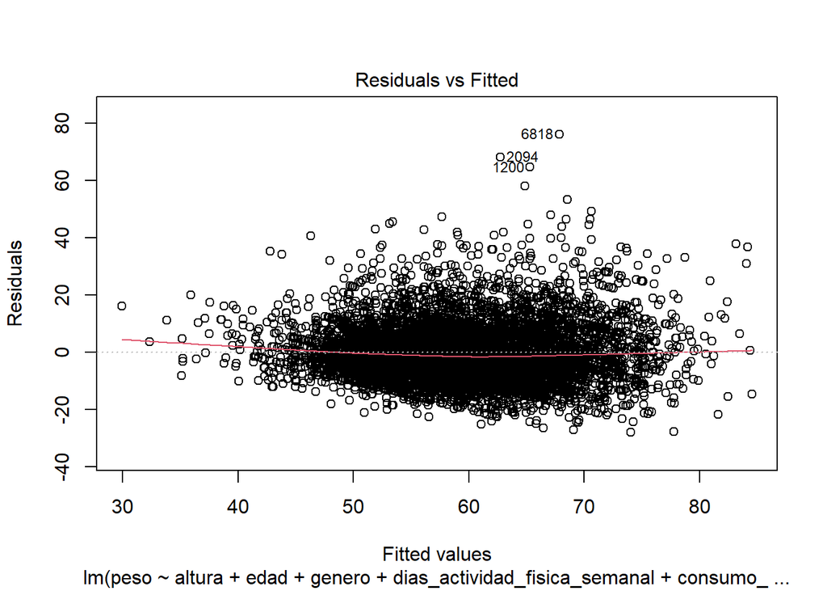

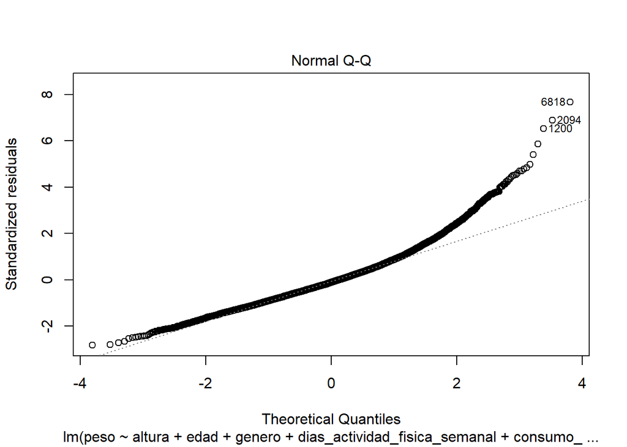

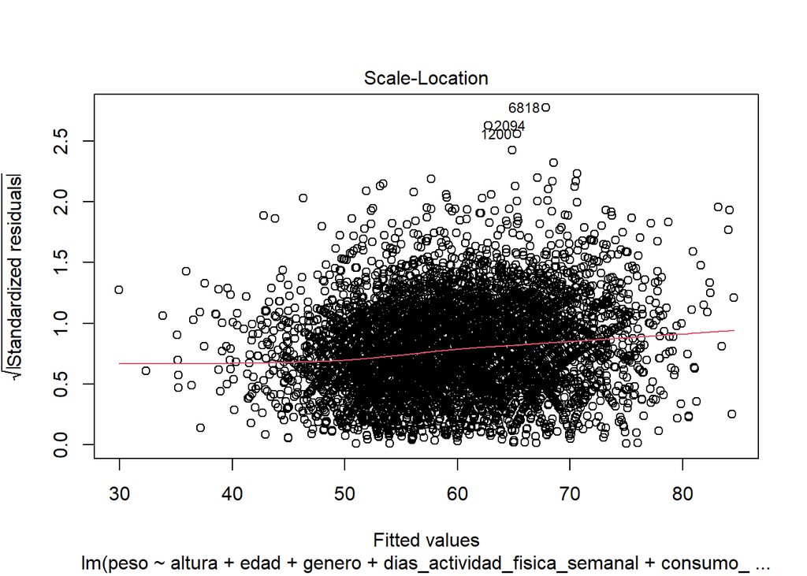

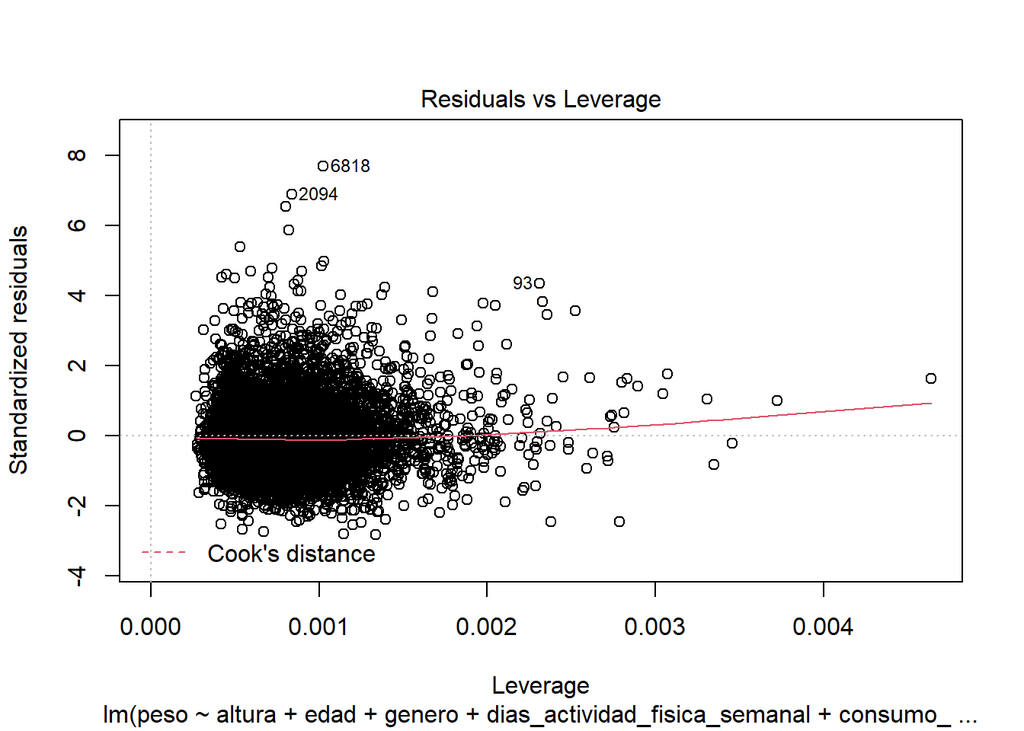

```r
plot(modelo_inicial)
```

En función de los gráficos, se puede evaluar que:

1. Residuos vs. valores predichos: la curvatura es sumamente leve, pero esta hace que no se pueda confirmar que la varianza sea constante, lo que implica que el supuesto de homocedasticidad no se pueda dar por aceptado en este caso.
2. Normalidad de los errores: el normal Q-Q plot muestra que, principalmente en los extremos altos, no se ajusta para nada a la distribución teórica coincidente con la normalidad, por lo tanto, el supuesto de la distribución normal de los residuos no se cumple.
3. Hay observaciones con un leverage elevado, lo que las hace influyente para el modelo y pueden violar el supuesto de independencia.

## Modelo robusto

**Leer el archivo “encuesta_salud_modelo6.csv”. Este último consiste en el dataset original de train con la incorporación de algunas observaciones adicionales que pueden incluir valores atípicos. En particular, observar la relación entre peso y altura ¿Qué ocurre con estos nuevos datos?**

```r
modelo6 <- read.csv('encuesta_salud_modelo6.csv', encoding = 'UTF-8')
reactable(head(modelo6))
```

| record | edad | genero | nivel_educativo | altura | peso | frecuencia_hambre_mensual | dias_consumo_comida_rapida | edad_consumo_alcohol | consumo_diario_alcohol | dias_actividad_fisica_semanal | consumo_semanal_frutas | consumo_semanal_verdura | consumo_semanal_gaseosas | consumo_semanal_snacks | consumo_semanal_comida_grasa |
| --- | --- | --- | --- | --- | --- | --- | --- | --- | --- | --- | --- | --- | --- | --- | --- |
| 48568 | 17 | Femenino | 3er año/12vo grado nivel Polimodal o 5to año nivel Secundario | 160 | 51 | Nunca | 1 | 12 o 13 años | 5 | 2 | 4 a 6 veces durante los últimos 7 días | 4 a 6 veces durante los últimos 7 días | 4 a 6 veces durante los últimos 7 días | 1 a 3 veces durante los últimos 7 días | 4 a 6 veces durante los últimos 7 días |
| 39818 | 14 | Masculino | 9no grado nivel Primario/Polimodal o 2do año nivel Secundario | 189 | 75 | Nunca | 0 | Nunca tomé alcohol más que unos pocos sorbos | 0 | 0 | 2 veces al día | 1 a 3 veces durante los últimos 7 días | 1 a 3 veces durante los últimos 7 días | 1 a 3 veces durante los últimos 7 días | 1 a 3 veces durante los últimos 7 días |
| 11360 | 16 | Masculino | 2do año/11vo grado nivel Polimodal o 4to año nivel Secundario | 166 | 50 | Nunca | 0 | 14 o 15 años | 0 | 0 | 1 a 3 veces durante los últimos 7 días | 4 a 6 veces durante los últimos 7 días | 1 a 3 veces durante los últimos 7 días | No comí comida salada o snacks en los últimos 7 días | No comí comida alta en grasa en los últimos 7 días |
| 50320 | 14 | Masculino | 9no grado nivel Primario/Polimodal o 2do año nivel Secundario | 178 | 80 | Nunca | 1 | Nunca tomé alcohol más que unos pocos sorbos | 0 | 2 | No comí frutas durante los últimos 7 días | 1 a 3 veces durante los últimos 7 días | 1 vez al día | 1 a 3 veces durante los últimos 7 días | 1 a 3 veces durante los últimos 7 días |
| 26325 | 15 | Masculino | Dato perdido | 167 | 50 | Nunca | 0 | Nunca tomé alcohol más que unos pocos sorbos | 0 | 1 | 1 a 3 veces durante los últimos 7 días | 4 a 6 veces durante los últimos 7 días | 1 a 3 veces durante los últimos 7 días | 1 a 3 veces durante los últimos 7 días | 1 a 3 veces durante los últimos 7 días |
| 44811 | 13 | Femenino | 1er año/10mo grado nivel Polimodal o 3er año nivel Secundario | 164 | 55 | Nunca | 0 | 8 o 9 años | 0 | 3 | 1 a 3 veces durante los últimos 7 días | 4 o más veces al día | 4 a 6 veces durante los últimos 7 días | No comí comida salada o snacks en los últimos 7 días | 1 vez al día |

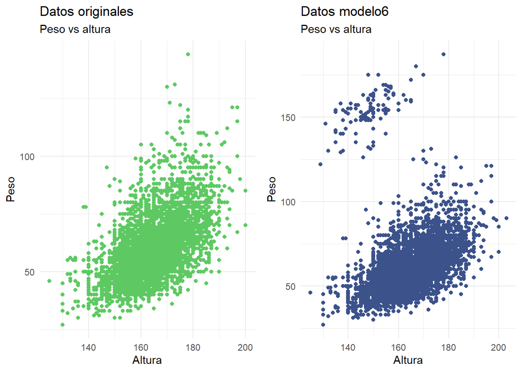

```r
originales <- ggplot() +
  geom_point(data = train, aes(x = altura, y = peso), color = "#5ec962") +
  theme_minimal() +
  labs(x="Altura", y="Peso",
       title = "Datos originales", subtitle = "Peso vs altura")

nuevos <- ggplot() +
  geom_point(data = modelo6, aes(x = altura, y = peso), color = "#3b528b") +
  theme_minimal() +
  labs(x="Altura", y="Peso",
       title = "Datos modelo6", subtitle = "Peso vs altura")

plot_grid(originales, nuevos)
```

```r
cor_original <- train %>%
  select(peso, altura) %>%
  correlate(method = 'spearman') %>%
  shave() %>%
  fashion()

cor_nueva <- modelo6 %>%
  select(peso, altura) %>%
  correlate(method = 'spearman') %>%
  shave() %>%
  fashion()
(cor_nueva$peso)
```

```
## [1]       .53
```

Los nuevos datos introducen una importante cantidad de datos atípicos con pesos muy elevados. Esto no implica necesariamente que sean datos erróneos, pero sí poco frecuentes. Estas nuevas observaciones introducen un cambio en la relación entre las variables, que se expresa en una menor correlación de Spearman entre peso y altura. Mientras que en los datos originales la correlación de Spearman entre peso y altura tenía un valor de .59, en el caso del nuevo dataset este valor se reduce a .53.

#### Modelo lineal con nuevos datos

**Entrenar el modelo inicial con estos nuevos datos y comentar qué se observa en los coeficientes estimados y las métricas de evaluación (R cuadrado ajustado, RMSE y MAE) respecto al modelo entrenado con el set de entrenamiento original**

```r
modelo_nuevo <- lm(peso ~ altura + edad + genero + dias_actividad_fisica_semanal + consumo_diario_alcohol,
                     data = modelo6)

reactable(tidy(modelo_nuevo, conf.int = TRUE))
```

| term | estimate | std.error | statistic | p.value | conf.low | conf.high |
| --- | --- | --- | --- | --- | --- | --- |
| (Intercept) | -26.2871001447847 | 3.6613655036524 | -7.17958917746998 | 7.69958942535239e-13 | -33.4644642650932 | -19.1097360244762 |
| altura | 0.352009083825205 | 0.0223809011343449 | 15.7281014608042 | 8.05797734442152e-55 | 0.308135868594009 | 0.395882299056402 |
| edad | 1.86858987297966 | 0.147740559008868 | 12.6477785485264 | 2.81918942730966e-36 | 1.57897448596441 | 2.15820525999491 |
| generoMasculino | 3.3130528853033 | 0.429223766831823 | 7.7187079125593 | 1.33565260980528e-14 | 2.47164678679463 | 4.15445898381197 |
| dias_actividad_fisica_semanal | -0.102125141492834 | 0.0786196518172699 | -1.29897728026316 | 0.193993772240404 | -0.256243015696194 | 0.0519927327105258 |
| consumo_diario_alcohol | 0.00371961932483118 | 0.0969348750207695 | 0.0383723538513276 | 0.969391878516514 | -0.186301533517361 | 0.193740772167023 |

```r
reactable(glance(modelo_nuevo))
```

| r.squared | adj.r.squared | sigma | statistic | p.value | df | logLik | AIC | BIC | deviance | df.residual | nobs |
| --- | --- | --- | --- | --- | --- | --- | --- | --- | --- | --- | --- |
| 0.110099657628197 | 0.109474990814796 | 15.7515286817198 | 176.253412645163 | 2.22587580937232e-177 | 5 | -29766.8184052315 | 59547.636810463 | 59595.7402942208 | 1767292.20134204 | 7123 | 7129 |

Lógicamente, esta menor capacidad del modelo de explicar la variabilidad del peso conduce a **una menor capacidad de predicción**.

```r
pred_modelo_nuevo <- augment(modelo_nuevo)
pred_modelo_nuevo <- metrics(pred_modelo_nuevo, truth = peso, estimate = .fitted) %>%
  mutate(modelo = "modelo_datos_nuevos")%>%
  select(modelo, metrica = ".metric", 3) %>%
  filter(metrica %in% c("rmse", "mae"))

reactable(pred_modelo_nuevo)
```

| modelo | metrica | .estimate |
| --- | --- | --- |
| modelo_datos_nuevos | rmse | 15.7448987851026 |
| modelo_datos_nuevos | mae | 9.23314584311728 |

Mientras que los errores del modelo original habían sido de RMSE = 9,910 y MAE = 7,455, vemos que en el caso de entrenar un modelo lineal simple con los mismos parámetros pero sobre datos con muchos valores atípicos, estos resultados empeoran considerablemente.

En este nuevo modelo, el RMSE aumenta en un 58.87% y el MAE lo hace en un 23.85%.

#### Modelo robusto con nuevos datos

**Entrenar un modelo robusto con la misma especificación que el modelo inicial sobre los nuevos datos. Comparar los coeficientes y su performance (RMSE y MAE) respecto al modelo inicial no robusto entrenado en este punto. ¿Qué puede concluir al respecto?**

Para la construcción del modelo robustao se utiliza la función `lmrob` del paquete `robustbase`, por recomendación de la cátedra.

```r
modelo_robusto <- robustbase::lmrob(peso ~ altura + edad + genero + dias_actividad_fisica_semanal + consumo_diario_alcohol,
                     data = modelo6)

reactable(tidy(modelo_robusto, conf.int = TRUE))
```

| term | estimate | std.error | statistic | p.value | conf.low | conf.high |
| --- | --- | --- | --- | --- | --- | --- |
| (Intercept) | -64.4377363030084 | 2.2251467030112 | -28.9588709885095 | 2.02750282375499e-174 | -68.7989437012284 | -60.0765289047884 |
| altura | 0.625890152403882 | 0.0143677474283654 | 43.562162790266 | 0 | 0.597729884905317 | 0.654050419902446 |
| edad | 1.30768099687688 | 0.0859171920519458 | 15.2202483070705 | 1.66656833950432e-51 | 1.13928639480226 | 1.47607559895151 |
| generoMasculino | 1.09895602029145 | 0.25281138082654 | 4.34694046090224 | 1.39969338403802e-05 | 0.603454818989592 | 1.59445722159331 |
| dias_actividad_fisica_semanal | -0.039148297292755 | 0.0452335698256351 | -0.865469991505481 | 0.386810027243337 | -0.127804465043178 | 0.0495078704576675 |
| consumo_diario_alcohol | 0.029067308426001 | 0.0552873140270836 | 0.525750055641369 | 0.599078246553123 | -0.0792938358690389 | 0.137428452721041 |

Respecto de los coeficientes generados por el modelo robusto, se observa que:

- Por un lado, la **significatividad de las variables y sus coeficientes se vuelven a asemejar mucho con las expresadas en el modelo inicial**. Por ejemplo, la altura vuelve a tener la misma significativdad y casi el mismo coeficiente que en el modelo original. Es decir que por cada centímetro de más, el aumento del peso esperado es de 0,62kg. Casi el doble que en el modelo no robusto sobre los mismos datos.

- Por otro lado, incluso la **variabilidad explicada por el modelo aumenta considerablemente**, llevando el valor del R cuadrado un 0,38. Es decir, el modelo robusto explica un 38,88% de la variabilidad del peso, mientras que el modelo simple con estos datos solo explicaba un 11%. Cabe destacar que la salida del modelo robusto solo incluye el R cuadrado y no el R cuadrado ajustado, que sería más adecuado dada la cantidad de variables del modelo.

```r
reactable(glance(modelo_robusto))
```

| r.squared | sigma | df.residual |
| --- | --- | --- |
| 0.388791241240935 | 8.60907890962614 | 7123 |

#### Comparación de RMSE y MAE

```r
pred_modelo_robusto <- augment(modelo_robusto)
pred_modelo_robusto <- metrics(pred_modelo_robusto, truth = peso, estimate = .fitted) %>%
  mutate(modelo = "modelo_robusto_datos_nuevos")%>%
  select(modelo, metrica = ".metric", 3) %>%
  filter(metrica %in% c("rmse", "mae"))

reactable(rbind(pred_modelo_nuevo, pred_modelo_robusto))
```

| modelo | metrica | .estimate |
| --- | --- | --- |
| modelo_datos_nuevos | rmse | 15.7448987851026 |
| modelo_datos_nuevos | mae | 9.23314584311728 |
| modelo_robusto_datos_nuevos | rmse | 16.0965783846324 |
| modelo_robusto_datos_nuevos | mae | 8.75296608898691 |

Lo expresado en la tabla de resultados **refleja claramente la diferencia en la robutez de los modelos**, pero también de las métricas. En tanto se use una métrica robusta como el MAE, vemos que el error es menor en el caso del modelo lineal robusto que en el caso del modelo lineal original.

Por su parte, el RMSE, más sensible a los errores por valores atípicos, resulta más elevado en el caso del modelo robusto que en el caso del modelo original.

Más allá de la diferencia con esta segunda métrica, se concluye que ante datos que cuentan con observaciones atípicas, es mejor contar con el modelo lineal robusto y con una métrica robusta, que con el modelo lineal simple.